# Modeller

MSB 105 - Assignment 4

Sindre M. Espedal & Ole Alexander Bakkevik

```r
suppressPackageStartupMessages({
library(tidyverse)
library(lubridate)
library(modelr)
library(broom)
library(lmtest)
library(sandwich)
library(viridis)
})
```

Henter csv. filen:

```r
pm2 <- read_csv("data/pm2.csv", show_col_types = FALSE)
```

```
## * `` -> ...1
```

Muterer:

```r
pm2 <- pm2 %>%
  mutate(
    fnr = str_sub(knr, 1,2),
    aar_f = str_sub(aar)
  )
```

```r
head(pm2)
```

| ...1 | knr | aar | knavn | pm2 | Menn_ya_p | Kvinner_ya_p | Total_ya_p | inc_k1 | inc_k5 | uni_k_mf | uni_k_m | uni_k_f | uni_l_mf | uni_l_m | uni_l_f | Trade_p | fnr | aar_f |
| --- | --- | --- | --- | --- | --- | --- | --- | --- | --- | --- | --- | --- | --- | --- | --- | --- | --- | --- |
| 1 | 0101 | 2008 | Halden | 13427 | 59.74892 | 56.79763 | 58.26214 | 24.5 | 13.6 | 17.8 | 15.1 | 20.4 | 3.9 | 5.4 | 2.4 | 56266 | 01 | 2008 |
| 2 | 0101 | 2009 | Halden | 13095 | 59.77860 | 57.04693 | 58.40290 | 24.4 | 14.1 | 18.2 | 15.4 | 20.9 | 3.9 | 5.4 | 2.5 | 56366 | 01 | 2009 |
| 3 | 0101 | 2010 | Halden | 13832 | 59.64298 | 57.06300 | 58.34376 | 23.9 | 13.7 | 18.6 | 15.6 | 21.6 | 4.1 | 5.5 | 2.7 | 57210 | 01 | 2010 |
| 4 | 0101 | 2011 | Halden | 14915 | 59.84630 | 57.22382 | 58.53183 | 24.0 | 14.0 | 19.0 | 15.8 | 22.2 | 4.4 | 5.8 | 3.0 | 58010 | 01 | 2011 |
| 5 | 0101 | 2012 | Halden | 15473 | 59.45122 | 57.00467 | 58.22699 | 23.9 | 14.0 | 19.6 | 16.2 | 22.9 | 4.6 | 5.9 | 3.3 | 58787 | 01 | 2012 |
| 6 | 0101 | 2013 | Halden | 15461 | 58.97797 | 56.73872 | 57.85475 | 24.1 | 13.4 | 19.9 | 16.4 | 23.3 | 4.6 | 5.8 | 3.4 | 59453 | 01 | 2013 |

parse_factor funksjonen:

```r
pm2 %>%
  mutate(
    fnr = parse_factor(fnr, levels = fnr),
    aar_f = parse_factor(aar_f, levels = aar_f)
  )
```

| ...1 | knr | aar | knavn | pm2 | Menn_ya_p | Kvinner_ya_p | Total_ya_p | inc_k1 | inc_k5 | uni_k_mf | uni_k_m | uni_k_f | uni_l_mf | uni_l_m | uni_l_f | Trade_p | fnr | aar_f |
| --- | --- | --- | --- | --- | --- | --- | --- | --- | --- | --- | --- | --- | --- | --- | --- | --- | --- | --- |
| 1 | 0101 | 2008 | Halden | 13427 | 59.74892 | 56.79763 | 58.26214 | 24.5 | 13.6 | 17.8 | 15.1 | 20.4 | 3.9 | 5.4 | 2.4 | 56266 | 01 | 2008 |
| 2 | 0101 | 2009 | Halden | 13095 | 59.77860 | 57.04693 | 58.40290 | 24.4 | 14.1 | 18.2 | 15.4 | 20.9 | 3.9 | 5.4 | 2.5 | 56366 | 01 | 2009 |
| 3 | 0101 | 2010 | Halden | 13832 | 59.64298 | 57.06300 | 58.34376 | 23.9 | 13.7 | 18.6 | 15.6 | 21.6 | 4.1 | 5.5 | 2.7 | 57210 | 01 | 2010 |
| 4 | 0101 | 2011 | Halden | 14915 | 59.84630 | 57.22382 | 58.53183 | 24.0 | 14.0 | 19.0 | 15.8 | 22.2 | 4.4 | 5.8 | 3.0 | 58010 | 01 | 2011 |
| 5 | 0101 | 2012 | Halden | 15473 | 59.45122 | 57.00467 | 58.22699 | 23.9 | 14.0 | 19.6 | 16.2 | 22.9 | 4.6 | 5.9 | 3.3 | 58787 | 01 | 2012 |
| 6 | 0101 | 2013 | Halden | 15461 | 58.97797 | 56.73872 | 57.85475 | 24.1 | 13.4 | 19.9 | 16.4 | 23.3 | 4.6 | 5.8 | 3.4 | 59453 | 01 | 2013 |
| 7 | 0101 | 2014 | Halden | 17164 | 58.76014 | 56.72937 | 57.74260 | 23.9 | 13.5 | 20.6 | 17.0 | 24.0 | 4.9 | 6.1 | 3.8 | 63033 | 01 | 2014 |
| 8 | 0101 | 2015 | Halden | 17427 | 58.71457 | 56.84787 | 57.78159 | 24.0 | 13.7 | 21.0 | 17.2 | 24.8 | 5.2 | 6.4 | 4.1 | 63747 | 01 | 2015 |
| 9 | 0101 | 2016 | Halden | 18941 | 58.68940 | 56.64129 | 57.66763 | 24.0 | 13.8 | 21.4 | 17.4 | 25.4 | 5.4 | 6.5 | 4.4 | 65624 | 01 | 2016 |
| 10 | 0101 | 2017 | Halden | 20143 | 58.94138 | 56.85186 | 57.90192 | 23.7 | 14.0 | 21.6 | 17.5 | 25.7 | 5.6 | 6.5 | 4.7 | 65919 | 01 | 2017 |

[output cut: 2130 more lines]

muterer:

```r
pm2 <- pm2 %>%
  mutate(
    Trade_pc_100K = Trade_p/100000
  )
```

```r
head(pm2, n = 4)
```

| ...1 | knr | aar | knavn | pm2 | Menn_ya_p | Kvinner_ya_p | Total_ya_p | inc_k1 | inc_k5 | uni_k_mf | uni_k_m | uni_k_f | uni_l_mf | uni_l_m | uni_l_f | Trade_p | fnr | aar_f | Trade_pc_100K |
| --- | --- | --- | --- | --- | --- | --- | --- | --- | --- | --- | --- | --- | --- | --- | --- | --- | --- | --- | --- |
| 1 | 0101 | 2008 | Halden | 13427 | 59.74892 | 56.79763 | 58.26214 | 24.5 | 13.6 | 17.8 | 15.1 | 20.4 | 3.9 | 5.4 | 2.4 | 56266 | 01 | 2008 | 0.56266 |
| 2 | 0101 | 2009 | Halden | 13095 | 59.77860 | 57.04693 | 58.40290 | 24.4 | 14.1 | 18.2 | 15.4 | 20.9 | 3.9 | 5.4 | 2.5 | 56366 | 01 | 2009 | 0.56366 |
| 3 | 0101 | 2010 | Halden | 13832 | 59.64298 | 57.06300 | 58.34376 | 23.9 | 13.7 | 18.6 | 15.6 | 21.6 | 4.1 | 5.5 | 2.7 | 57210 | 01 | 2010 | 0.57210 |
| 4 | 0101 | 2011 | Halden | 14915 | 59.84630 | 57.22382 | 58.53183 | 24.0 | 14.0 | 19.0 | 15.8 | 22.2 | 4.4 | 5.8 | 3.0 | 58010 | 01 | 2011 | 0.58010 |

# Modell

```r
mod1 <- 'pm2 ~ aar_f + Total_ya_p + inc_k1 + inc_k5 + uni_k_mf + uni_l_mf + Trade_pc_100K'
```

```r
lm1 <- lm(mod1, data = pm2, subset = complete.cases(pm2))
```

```r
summary(lm1)
```

```
##
## Call:
## lm(formula = mod1, data = pm2, subset = complete.cases(pm2))
##
## Residuals:
##     Min      1Q  Median      3Q     Max
## -8516.6 -1472.1   -29.9  1467.3 15736.3
##
## Coefficients:
##                Estimate Std. Error t value Pr(>|t|)
## (Intercept)   -20400.74    2663.02  -7.661 2.79e-14 ***
## aar_f2009        104.15     244.77   0.426 0.670512
## aar_f2010        908.13     245.16   3.704 0.000217 ***
## aar_f2011       1663.93     245.86   6.768 1.68e-11 ***
## aar_f2012       2240.48     247.10   9.067  < 2e-16 ***
## aar_f2013       2869.30     248.31  11.555  < 2e-16 ***
## aar_f2014       2863.22     250.54  11.428  < 2e-16 ***
## aar_f2015       3525.22     253.08  13.929  < 2e-16 ***
## aar_f2016       4274.99     255.81  16.711  < 2e-16 ***
## aar_f2017       5146.33     258.50  19.909  < 2e-16 ***
## Total_ya_p       582.44      38.94  14.957  < 2e-16 ***
## inc_k1          -376.99      30.29 -12.445  < 2e-16 ***
## inc_k5           194.35      22.87   8.498  < 2e-16 ***
## uni_k_mf         -82.02      29.42  -2.788 0.005357 **
## uni_l_mf        1206.86      42.22  28.585  < 2e-16 ***
## Trade_pc_100K    871.99     218.42   3.992 6.77e-05 ***
## ---
## Signif. codes:  0 '***' 0.001 '**' 0.01 '*' 0.05 '.' 0.1 ' ' 1
##
## Residual standard error: 2531 on 2124 degrees of freedom
## Multiple R-squared:  0.8346, Adjusted R-squared:  0.8334
## F-statistic: 714.3 on 15 and 2124 DF,  p-value: < 2.2e-16
```

2. Legger til residualer:

```r
pm2 %>%
  add_residuals(lm1)
```

| ...1 | knr | aar | knavn | pm2 | Menn_ya_p | Kvinner_ya_p | Total_ya_p | inc_k1 | inc_k5 | uni_k_mf | uni_k_m | uni_k_f | uni_l_mf | uni_l_m | uni_l_f | Trade_p | fnr | aar_f | Trade_pc_100K | resid |
| --- | --- | --- | --- | --- | --- | --- | --- | --- | --- | --- | --- | --- | --- | --- | --- | --- | --- | --- | --- | --- |
| 1 | 0101 | 2008 | Halden | 13427 | 59.74892 | 56.79763 | 58.26214 | 24.5 | 13.6 | 17.8 | 15.1 | 20.4 | 3.9 | 5.4 | 2.4 | 56266 | 01 | 2008 | 0.56266 | 2749.432077 |
| 2 | 0101 | 2009 | Halden | 13095 | 59.77860 | 57.04693 | 58.40290 | 24.4 | 14.1 | 18.2 | 15.4 | 20.9 | 3.9 | 5.4 | 2.5 | 56366 | 01 | 2009 | 0.56366 | 2128.357974 |
| 3 | 0101 | 2010 | Halden | 13832 | 59.64298 | 57.06300 | 58.34376 | 23.9 | 13.7 | 18.6 | 15.6 | 21.6 | 4.1 | 5.5 | 2.7 | 57210 | 01 | 2010 | 0.57210 | 1769.151591 |
| 4 | 0101 | 2011 | Halden | 14915 | 59.84630 | 57.22382 | 58.53183 | 24.0 | 14.0 | 19.0 | 15.8 | 22.2 | 4.4 | 5.8 | 3.0 | 58010 | 01 | 2011 | 0.58010 | 1629.985324 |
| 5 | 0101 | 2012 | Halden | 15473 | 59.45122 | 57.00467 | 58.22699 | 23.9 | 14.0 | 19.6 | 16.2 | 22.9 | 4.6 | 5.9 | 3.3 | 58787 | 01 | 2012 | 0.58787 | 1552.352281 |
| 6 | 0101 | 2013 | Halden | 15461 | 58.97797 | 56.73872 | 57.85475 | 24.1 | 13.4 | 19.9 | 16.4 | 23.3 | 4.6 | 5.8 | 3.4 | 59453 | 01 | 2013 | 0.59453 | 1339.145831 |
| 7 | 0101 | 2014 | Halden | 17164 | 58.76014 | 56.72937 | 57.74260 | 23.9 | 13.5 | 20.6 | 17.0 | 24.0 | 4.9 | 6.1 | 3.8 | 63033 | 01 | 2014 | 0.63033 | 2682.849395 |
| 8 | 0101 | 2015 | Halden | 17427 | 58.71457 | 56.84787 | 57.78159 | 24.0 | 13.7 | 21.0 | 17.2 | 24.8 | 5.2 | 6.4 | 4.1 | 63747 | 01 | 2015 | 0.63747 | 1924.496260 |
| 9 | 0101 | 2016 | Halden | 18941 | 58.68940 | 56.64129 | 57.66763 | 24.0 | 13.8 | 21.4 | 17.4 | 25.4 | 5.4 | 6.5 | 4.4 | 65624 | 01 | 2016 | 0.65624 | 2510.739252 |
| 10 | 0101 | 2017 | Halden | 20143 | 58.94138 | 56.85186 | 57.90192 | 23.7 | 14.0 | 21.6 | 17.5 | 25.7 | 5.6 | 6.5 | 4.7 | 65919 | 01 | 2017 | 0.65919 | 2325.438501 |

[output cut: 2130 more lines]

```r
head(pm2, n = 4)
```

| ...1 | knr | aar | knavn | pm2 | Menn_ya_p | Kvinner_ya_p | Total_ya_p | inc_k1 | inc_k5 | uni_k_mf | uni_k_m | uni_k_f | uni_l_mf | uni_l_m | uni_l_f | Trade_p | fnr | aar_f | Trade_pc_100K |
| --- | --- | --- | --- | --- | --- | --- | --- | --- | --- | --- | --- | --- | --- | --- | --- | --- | --- | --- | --- |
| 1 | 0101 | 2008 | Halden | 13427 | 59.74892 | 56.79763 | 58.26214 | 24.5 | 13.6 | 17.8 | 15.1 | 20.4 | 3.9 | 5.4 | 2.4 | 56266 | 01 | 2008 | 0.56266 |
| 2 | 0101 | 2009 | Halden | 13095 | 59.77860 | 57.04693 | 58.40290 | 24.4 | 14.1 | 18.2 | 15.4 | 20.9 | 3.9 | 5.4 | 2.5 | 56366 | 01 | 2009 | 0.56366 |
| 3 | 0101 | 2010 | Halden | 13832 | 59.64298 | 57.06300 | 58.34376 | 23.9 | 13.7 | 18.6 | 15.6 | 21.6 | 4.1 | 5.5 | 2.7 | 57210 | 01 | 2010 | 0.57210 |
| 4 | 0101 | 2011 | Halden | 14915 | 59.84630 | 57.22382 | 58.53183 | 24.0 | 14.0 | 19.0 | 15.8 | 22.2 | 4.4 | 5.8 | 3.0 | 58010 | 01 | 2011 | 0.58010 |

Man leser ut gjennomsnittlig kvadratmeterpris for en enebolig ($pm2$) for de forskjellige årene. Vi ser at $pm2$ stiger jevnt og trutt.

Vi vil si at fortegnene er som forventet. Dersom vi har tolket modellen riktig, så vil $pm2$ være mindre for dem nederste kvintilen (*inc_k1*) enn for den øverste (*inc_k5*). Det samme gjelder for de med kort og lang utdanning.

Dette er nok fordi den rikere delen av befolkninge, og de med høyere utdanning, sannsynligvis har mer attraktive eneboliger som gjør at $pm2$ er høyere.

## Heteroskedastisitet

### i.

```r
bptest(lm1)
```

```
##
##  studentized Breusch-Pagan test
##
## data:  lm1
## BP = 352.89, df = 15, p-value < 2.2e-16
```

### iii.

```r
coeftest(lm1)
```

```
##
## t test of coefficients:
##
##                 Estimate Std. Error  t value  Pr(>|t|)
## (Intercept)   -20400.742   2663.022  -7.6607 2.790e-14 ***
## aar_f2009        104.150    244.767   0.4255 0.6705118
## aar_f2010        908.129    245.156   3.7043 0.0002174 ***
## aar_f2011       1663.926    245.857   6.7679 1.685e-11 ***
## aar_f2012       2240.475    247.095   9.0672 < 2.2e-16 ***
## aar_f2013       2869.297    248.315  11.5551 < 2.2e-16 ***
## aar_f2014       2863.224    250.537  11.4283 < 2.2e-16 ***
## aar_f2015       3525.223    253.083  13.9291 < 2.2e-16 ***
## aar_f2016       4274.990    255.812  16.7114 < 2.2e-16 ***
## aar_f2017       5146.326    258.498  19.9086 < 2.2e-16 ***
## Total_ya_p       582.436     38.941  14.9568 < 2.2e-16 ***
## inc_k1          -376.989     30.291 -12.4455 < 2.2e-16 ***
## inc_k5           194.354     22.871   8.4979 < 2.2e-16 ***
## uni_k_mf         -82.023     29.424  -2.7876 0.0053574 **
## uni_l_mf        1206.857     42.219  28.5853 < 2.2e-16 ***
## Trade_pc_100K    871.993    218.422   3.9922 6.768e-05 ***
## ---
## Signif. codes:  0 '***' 0.001 '**' 0.01 '*' 0.05 '.' 0.1 ' ' 1
```

```r
vcovHC(lm1)
```

```
##               (Intercept)    aar_f2009   aar_f2010   aar_f2011   aar_f2012
## (Intercept)    9297989.37 -26519.17426 -34751.3931 -64358.9799 -88195.7750
## aar_f2009       -26519.17  42579.51052  22306.6988  22379.0191  22461.1963
## aar_f2010       -34751.39  22306.69876  41857.2132  22643.0594  22816.5776
## aar_f2011       -64358.98  22379.01911  22643.0594  45210.7304  23406.9880
## aar_f2012       -88195.78  22461.19628  22816.5776  23406.9880  47055.4187
## aar_f2013       -93332.22  22562.49160  23016.0483  23690.1311  24270.5328
## aar_f2014      -128032.51  22647.20878  23232.1454  24076.5421  24791.9383
## aar_f2015      -177893.27  22637.74268  23267.9132  24237.7165  25055.0255
## aar_f2016      -229170.12  22623.80635  23323.0788  24446.1520  25385.7301
## aar_f2017      -231919.09  22624.44448  23352.3686  24515.4258  25408.7607
## Total_ya_p     -134378.95     89.41919    277.8154    681.8928   1112.5721
## inc_k1          -48847.48    -46.78668   -117.7882    188.8338    193.4766
## inc_k5          -26724.41    110.78484    126.8286    397.1950    455.5137
## uni_k_mf        -23624.40   -129.42390   -212.3787   -468.5265   -572.7298
## uni_l_mf         79213.28    -45.36231   -237.3954   -324.3915   -491.9711
## Trade_pc_100K   145568.84    497.16540   1261.8579    987.3383    936.1196
##                  aar_f2013    aar_f2014    aar_f2015    aar_f2016    aar_f2017
## (Intercept)   -93332.21682 -128032.5143 -177893.2733 -229170.1243 -231919.0869
## aar_f2009      22562.49160   22647.2088   22637.7427   22623.8064   22624.4445
## aar_f2010      23016.04825   23232.1454   23267.9132   23323.0788   23352.3686
## aar_f2011      23690.13111   24076.5421   24237.7165   24446.1520   24515.4258
## aar_f2012      24270.53282   24791.9383   25055.0255   25385.7301   25408.7607
## aar_f2013      49220.90256   25428.8815   25755.4473   26135.5595   26169.5465
## aar_f2014      25428.88146   53475.4422   27156.8674   27482.0673   27045.3309
## aar_f2015      25755.44730   27156.8674   63394.1122   28309.5656   27655.2812
## aar_f2016      26135.55952   27482.0673   28309.5656   75087.4602   28071.1160
## aar_f2017      26169.54649   27045.3309   27655.2812   28071.1160   89424.5717
## Total_ya_p      1311.74280    1662.7240    2349.7551    3130.9906    3266.6554
## inc_k1           -23.25608     237.9932     438.1822     706.9105     723.9683
## inc_k5           419.80206     750.9501     927.6337    1166.2786    1178.1709
## uni_k_mf        -695.90501    -198.2867     136.4018    -110.1222    -816.2879
## uni_l_mf        -632.27758   -2195.0185   -3034.7846   -2540.7427   -1110.7783
## Trade_pc_100K   2510.69810    2684.4013    2764.2300     282.6406    1862.4720
##                  Total_ya_p       inc_k1      inc_k5     uni_k_mf    uni_l_mf
## (Intercept)   -134378.94615 -48847.47803 -26724.4053 -23624.40438 79213.27980
## aar_f2009          89.41919    -46.78668    110.7848   -129.42390   -45.36231
## aar_f2010         277.81538   -117.78822    126.8286   -212.37867  -237.39541
## aar_f2011         681.89276    188.83384    397.1950   -468.52650  -324.39148
## aar_f2012        1112.57212    193.47663    455.5137   -572.72977  -491.97106
```

[output cut: 13 more lines]

```
## aar_f2009          497.1654
## aar_f2010         1261.8579
## aar_f2011          987.3383
## aar_f2012          936.1196
## aar_f2013         2510.6981
## aar_f2014         2684.4013
## aar_f2015         2764.2300
## aar_f2016          282.6406
## aar_f2017         1862.4720
## Total_ya_p       -1619.3416
## inc_k1           -2293.0328
## inc_k5            -115.1786
## uni_k_mf         -2608.7728
## uni_l_mf           651.9410
## Trade_pc_100K    60897.1826
```

### iv.

```r
pm2 <- pm2 %>%
  add_residuals(lm1)
```

### v.

```r
pm2 <- pm2 %>%
  mutate(aar_d = make_date(aar))
```

### vi.

```r
pm2 <- pm2 %>%
  mutate(fylke = substr(knr, start = 1, stop = 2))
```

## vii -x.

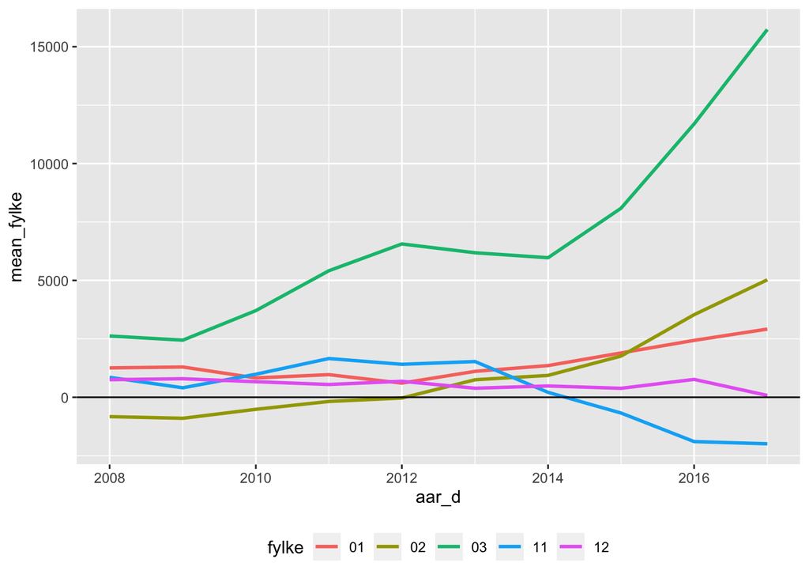

```r
pm2 %>%
  filter(fylke %in% c("01", "02", "03", "11", "12")) %>%
  unnest(c(fylke)) %>%
  group_by(fylke, aar_d) %>%
  summarize(mean_fylke = mean(resid)
            ) %>%
  ggplot(aes(x = aar_d, y = mean_fylke, colour = fylke)) +
  geom_line(lwd=1) +
  theme(legend.position = "bottom")+
  geom_hline(yintercept = 0, colour = "black")
```

# Dummy fylke og år

## i & ii.

```r
mod2 <- 'pm2 ~ aar_f*fnr + Total_ya_p + inc_k1 + inc_k5 + uni_k_mf + uni_l_mf + Trade_pc_100K'

lm2 <- lm(mod2, data = pm2)

summary(lm2)
```

```
##
## Call:
## lm(formula = mod2, data = pm2)
##
## Residuals:
##    Min     1Q Median     3Q    Max
##  -8546  -1191     32   1198   8328
##
## Coefficients:
##                   Estimate Std. Error t value Pr(>|t|)
## (Intercept)     -21200.688   2521.645  -8.407  < 2e-16 ***
## aar_f2009           94.009    744.240   0.126 0.899496
## aar_f2010          417.129    744.379   0.560 0.575290
## aar_f2011         1280.914    744.731   1.720 0.085597 .
## aar_f2012         1455.525    745.679   1.952 0.051088 .
## aar_f2013         2479.533    746.367   3.322 0.000910 ***
## aar_f2014         2795.831    747.254   3.741 0.000188 ***
## aar_f2015         3987.973    748.109   5.331 1.09e-07 ***
## aar_f2016         5264.965    749.169   7.028 2.89e-12 ***
## aar_f2017         6618.572    749.430   8.831  < 2e-16 ***
## fnr02            -1482.789    702.970  -2.109 0.035045 *
## fnr03             3248.234   2190.443   1.483 0.138260
## fnr04            -1049.219    774.264  -1.355 0.175537
## fnr05            -1937.388    758.293  -2.555 0.010696 *
## fnr06            -2172.731    772.094  -2.814 0.004941 **
## fnr07             -737.995   1080.348  -0.683 0.494620
## fnr08            -3213.279    878.620  -3.657 0.000262 ***
## fnr09            -1219.813    913.691  -1.335 0.182020
## fnr10             -281.375    852.265  -0.330 0.741323
## fnr11             -565.360    771.927  -0.732 0.464012
## fnr12             -903.071    742.464  -1.216 0.224012
## fnr14            -3339.829   1182.013  -2.826 0.004768 **
## fnr15            -3619.198    715.832  -5.056 4.69e-07 ***
## fnr16            -1093.217    759.677  -1.439 0.150296
## fnr17            -2005.965    917.216  -2.187 0.028860 *
## fnr18            -1567.503    774.530  -2.024 0.043126 *
## fnr19            -2856.881   1326.142  -2.154 0.031341 *
## fnr20            -2656.315   1180.088  -2.251 0.024500 *
## Total_ya_p         511.787     36.100  14.177  < 2e-16 ***
## inc_k1            -243.050     27.007  -9.000  < 2e-16 ***
```

[output cut: 157 more lines]

```
## aar_f2009:fnr20   -927.061   1664.164  -0.557 0.577542
## aar_f2010:fnr20   -547.207   1664.063  -0.329 0.742313
## aar_f2011:fnr20   -542.321   1664.293  -0.326 0.744568
## aar_f2012:fnr20   -378.342   1664.741  -0.227 0.820240
## aar_f2013:fnr20  -1110.163   1664.836  -0.667 0.504960
## aar_f2014:fnr20  -1563.827   1665.176  -0.939 0.347778
## aar_f2015:fnr20  -3266.760   1665.444  -1.961 0.049964 *
## aar_f2016:fnr20  -3169.910   1665.821  -1.903 0.057200 .
## aar_f2017:fnr20  -3922.387   1665.464  -2.355 0.018615 *
## ---
## Signif. codes:  0 '***' 0.001 '**' 0.01 '*' 0.05 '.' 0.1 ' ' 1
##
## Residual standard error: 2105 on 1944 degrees of freedom
## Multiple R-squared:  0.8953, Adjusted R-squared:  0.8848
## F-statistic: 85.21 on 195 and 1944 DF,  p-value: < 2.2e-16
```

## iii.

```r
pm2 <- pm2 %>%
  mutate(res_m2 = resid(lm2))
```

## iv.

Delplott:

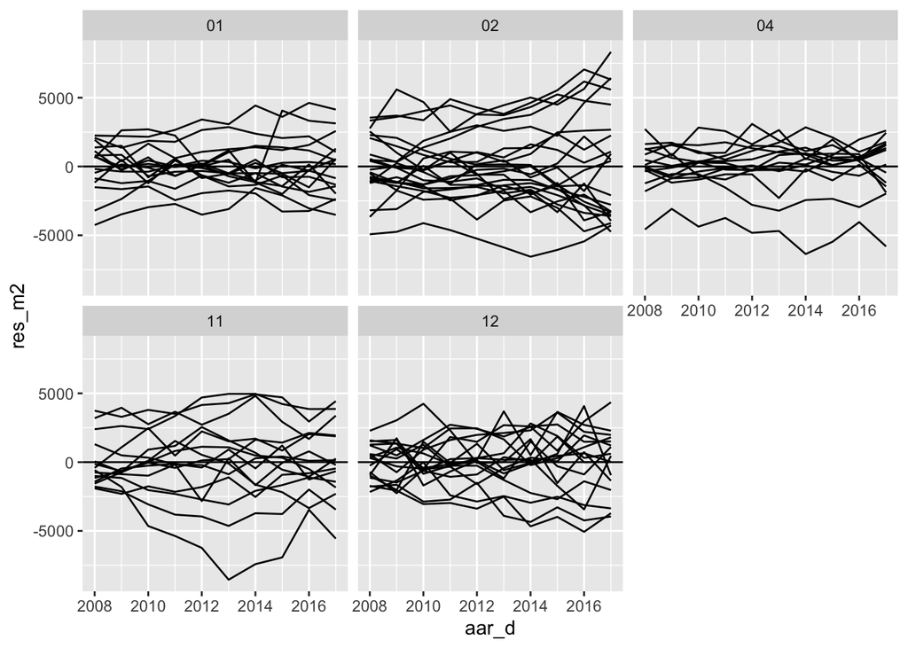

```r
pm2 %>% filter(fnr %in% c("01", "02", "04", "11", "12")) %>%
ggplot(mapping = aes(x = aar_d, y = res_m2)) +
geom_line(aes(group = knavn)) +
scale_size_manual(values = c(seq(2.0, 0.5, by = -0.1))) +
geom_hline(yintercept = 0) +
theme(legend.position = 'bottom') +
  facet_wrap(~fylke)
```

## i & ii.

Kvaliteten på modellen er ikke helt optimal da den mangler noen variabler. Dette kan ha noe med heteroskedatisitet i modell at det er stor variasjon. Det er store residualer, spesielt i Rogaland.

Ut i fra grafene så ser man at variasjonen er stor. Dette indikerer et heteroskedastisitetsproblem, og dermed er det grunn til at det er utelatte viktige variabler (brudd på TS.3/TS’.3)

## iii.

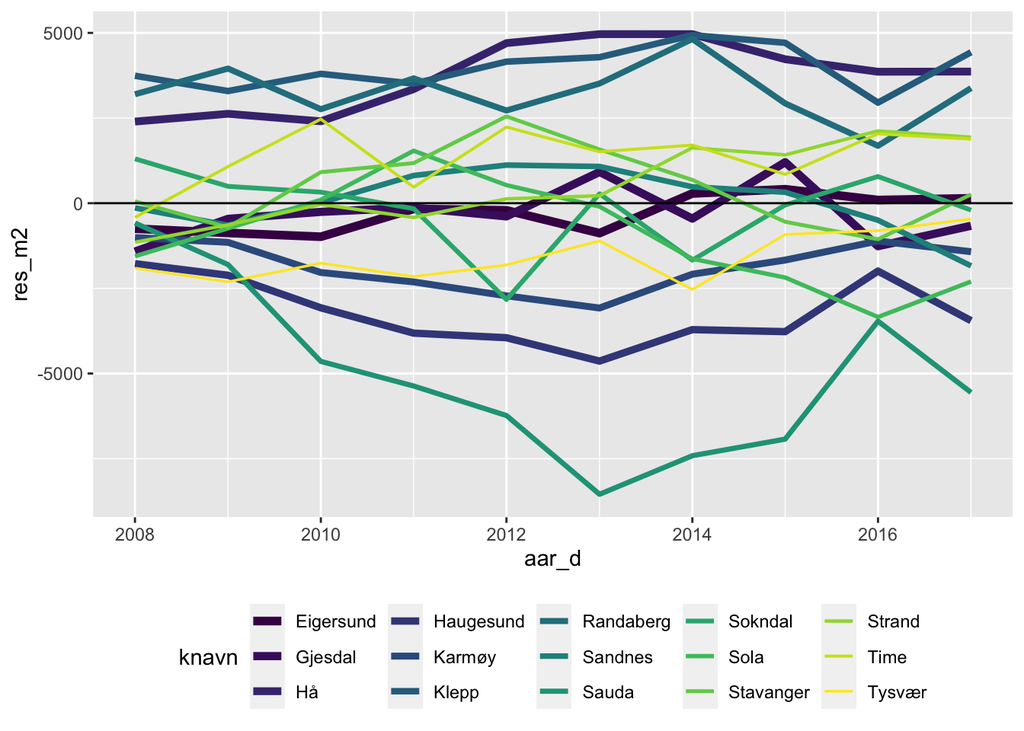

```r
pm2 %>% filter(fnr %in% c("11")) %>%
ggplot(mapping = aes(x = aar_d, y = res_m2)) +
scale_color_viridis(discrete = TRUE, option = "D") +
geom_line(aes(group = knavn, colour = knavn, size =knavn)) +
scale_size_manual(values = c(seq(2.0, 0.5, by = -0.1))) +
geom_hline(yintercept = 0) +
theme(legend.position = 'bottom')
```

## i.

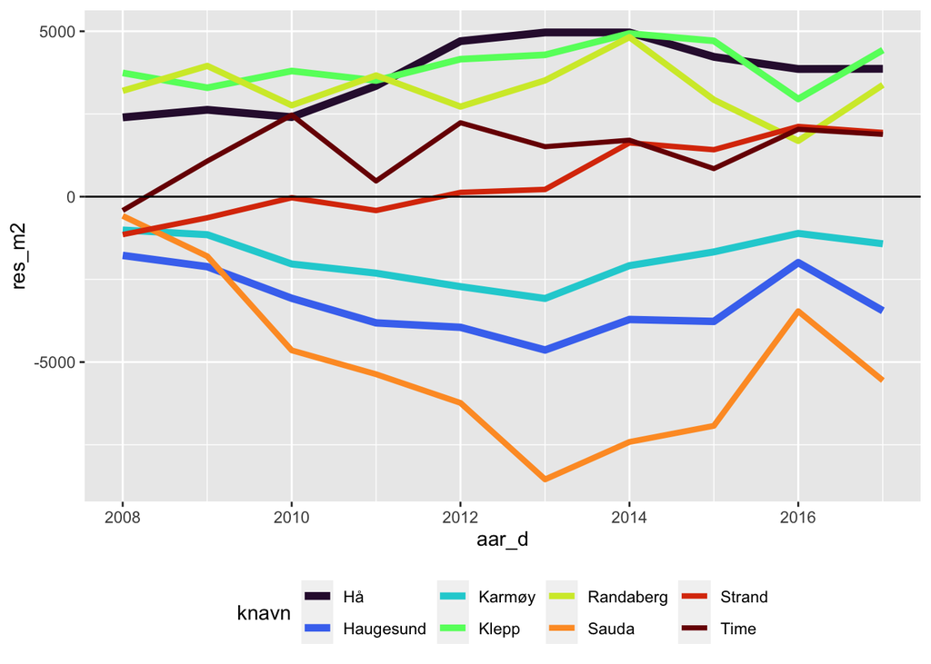

```r
pm2 %>% filter(knr %in% c("1119", "1120", "1127", "1121", "1130", "1135", "1106", "1149")) %>%
ggplot(mapping = aes(x = aar_d, y = res_m2)) +
scale_color_viridis(discrete = TRUE, option = "H") +
geom_line(aes(group = knavn, colour = knavn, size =knavn)) +
scale_size_manual(values = c(seq(2.0, 0.5, by = -0.1))) +
geom_hline(yintercept = 0) +
theme(legend.position = 'bottom')
```

## ii.

# Modell for hvert år

## i.

```r
pm2_n <- pm2 %>%
  select(pm2, fnr, knr, aar, aar_f, aar_d, Menn_ya_p, Kvinner_ya_p, Total_ya_p, inc_k1, inc_k5, uni_k_mf, uni_l_mf, Trade_pc_100K) %>%
  group_by(aar_d) %>%
  nest()
```

```r
pm2_n
```

| aar_d | data |
| --- | --- |
| 2008-01-01 |  |
| 2009-01-01 |  |
| 2010-01-01 |  |
| 2011-01-01 |  |
| 2012-01-01 |  |
| 2013-01-01 |  |
| 2014-01-01 |  |
| 2015-01-01 |  |
| 2016-01-01 |  |
| 2017-01-01 |  |

```r
pm2_n$data[[1]] %>%
head(n = 5)
```

| pm2 | fnr | knr | aar | aar_f | Menn_ya_p | Kvinner_ya_p | Total_ya_p | inc_k1 | inc_k5 | uni_k_mf | uni_l_mf | Trade_pc_100K |
| --- | --- | --- | --- | --- | --- | --- | --- | --- | --- | --- | --- | --- |
| 13427 | 01 | 0101 | 2008 | 2008 | 59.74892 | 56.79763 | 58.26214 | 24.5 | 13.6 | 17.8 | 3.9 | 0.56266 |
| 18299 | 01 | 0104 | 2008 | 2008 | 60.69851 | 58.67423 | 59.66705 | 22.8 | 16.2 | 19.1 | 5.5 | 0.69916 |
| 14981 | 01 | 0105 | 2008 | 2008 | 60.89855 | 58.06389 | 59.47153 | 22.2 | 13.6 | 16.3 | 2.8 | 0.63674 |
| 15671 | 01 | 0106 | 2008 | 2008 | 59.81091 | 57.82070 | 58.79460 | 21.8 | 16.2 | 19.0 | 4.3 | 0.69040 |
| 18844 | 01 | 0111 | 2008 | 2008 | 61.67247 | 61.27049 | 61.47438 | 17.8 | 19.0 | 18.3 | 4.7 | 0.75027 |

```r
dim(pm2_n)
```

```
## [1] 10  2
```

## i.

Funksjon **kom_model**:

```r
kom_model <- function(a_df) {
  lm(pm2 ~ fnr + Total_ya_p + inc_k1 + inc_k5 + uni_k_mf + uni_l_mf + Trade_pc_100K, data = a_df)
}
```

```r
pm2_n <- pm2_n %>%
  mutate(
    model = map(data, .f = kom_model)
    )
```

## i.

```r
pm2_n %>%
  filter(aar_d == "2008-01-01") %>%
  .$model %>%
  .[[1]] %>%
  summary()
```

```
##
## Call:
## lm(formula = pm2 ~ fnr + Total_ya_p + inc_k1 + inc_k5 + uni_k_mf +
##     uni_l_mf + Trade_pc_100K, data = a_df)
##
## Residuals:
##     Min      1Q  Median      3Q     Max
## -4643.7 -1014.1   -62.3  1049.1  4422.7
##
## Coefficients:
##                Estimate Std. Error t value Pr(>|t|)
## (Intercept)   -21323.12    6210.25  -3.434 0.000732 ***
## fnr02            270.94     646.91   0.419 0.675827
## fnr03           4881.16    1955.07   2.497 0.013392 *
## fnr04          -1918.28     648.11  -2.960 0.003472 **
## fnr05          -2448.43     624.11  -3.923 0.000122 ***
## fnr06          -1689.23     636.36  -2.655 0.008619 **
## fnr07           -386.22     887.87  -0.435 0.664063
## fnr08          -3418.79     721.55  -4.738 4.23e-06 ***
## fnr09          -1056.76     756.64  -1.397 0.164159
## fnr10           -259.64     720.32  -0.360 0.718918
## fnr11            495.00     715.93   0.691 0.490161
## fnr12           -348.05     662.35  -0.525 0.599862
## fnr14          -2658.06     996.48  -2.667 0.008306 **
## fnr15          -3331.71     653.36  -5.099 8.25e-07 ***
## fnr16          -1283.11     634.47  -2.022 0.044550 *
## fnr17          -2437.25     782.79  -3.114 0.002136 **
## fnr18          -2049.05     660.42  -3.103 0.002212 **
## fnr19          -2995.65    1083.85  -2.764 0.006277 **
## fnr20          -2254.93     977.89  -2.306 0.022200 *
## Total_ya_p       464.29      90.03   5.157 6.31e-07 ***
## inc_k1           -50.14      71.27  -0.703 0.482632
## inc_k5           233.05      57.31   4.066 7.00e-05 ***
## uni_k_mf         181.57      74.45   2.439 0.015662 *
## uni_l_mf         554.37     126.50   4.382 1.94e-05 ***
## Trade_pc_100K   1028.58     530.45   1.939 0.053982 .
## ---
## Signif. codes:  0 '***' 0.001 '**' 0.01 '*' 0.05 '.' 0.1 ' ' 1
##
## Residual standard error: 1701 on 189 degrees of freedom
## Multiple R-squared:  0.873,  Adjusted R-squared:  0.8569
## F-statistic: 54.15 on 24 and 189 DF,  p-value: < 2.2e-16
```

## i.

```r
mod_sum <- pm2_n %>%
  mutate(
    mod_summary = map(.x = model, .f = glance)
    ) %>%
  unnest(mod_summary) %>%
  print()
```

```
## # A tibble: 10 × 15
## # Groups:   aar_d [10]
##    aar_d      data  model r.squared adj.r.squared sigma statistic  p.value    df
##    <date>     <lis> <lis>     <dbl>         <dbl> <dbl>     <dbl>    <dbl> <dbl>
##  1 2008-01-01 <tib… <lm>      0.873         0.857 1701.      54.2 1.19e-71    24
##  2 2009-01-01 <tib… <lm>      0.886         0.871 1614.      61.2 5.63e-76    24
##  3 2010-01-01 <tib… <lm>      0.888         0.874 1743.      62.4 1.13e-76    24
##  4 2011-01-01 <tib… <lm>      0.883         0.868 1925.      59.4 6.50e-75    24
##  5 2012-01-01 <tib… <lm>      0.891         0.877 1953.      64.2 1.06e-77    24
##  6 2013-01-01 <tib… <lm>      0.895         0.881 2026.      67.0 3.03e-79    24
##  7 2014-01-01 <tib… <lm>      0.884         0.869 2149.      60.1 2.30e-75    24
##  8 2015-01-01 <tib… <lm>      0.879         0.863 2361.      57.1 1.57e-73    24
##  9 2016-01-01 <tib… <lm>      0.883         0.869 2467.      59.7 4.19e-75    24
## 10 2017-01-01 <tib… <lm>      0.895         0.882 2614.      67.0 2.84e-79    24
## # … with 6 more variables: logLik <dbl>, AIC <dbl>, BIC <dbl>, deviance <dbl>,
## #   df.residual <int>, nobs <int>
```

```r
coef_df <- mod_sum$model %>%
  map_df(1) %>%
  tibble()
```

## i.

Lager ny variabel (*aar*) i **coef_df**:

```r
coef_df <- coef_df %>%
  mutate(
    aar = ymd(paste(2008:2017,
                    "-01-01",
                    sep = ""))
  ) %>%
  select(aar, everything())
```

## ii.

Pivot_longer funksjonen: **coef_df** til **coef_df_long**.

```r
coef_df_long <- coef_df %>%
  pivot_longer(
    cols = `(Intercept)`:`Trade_pc_100K`,
    names_to = "variables",
    values_to = "coef")
```

## iii.

Plott av utvalgte fylker:

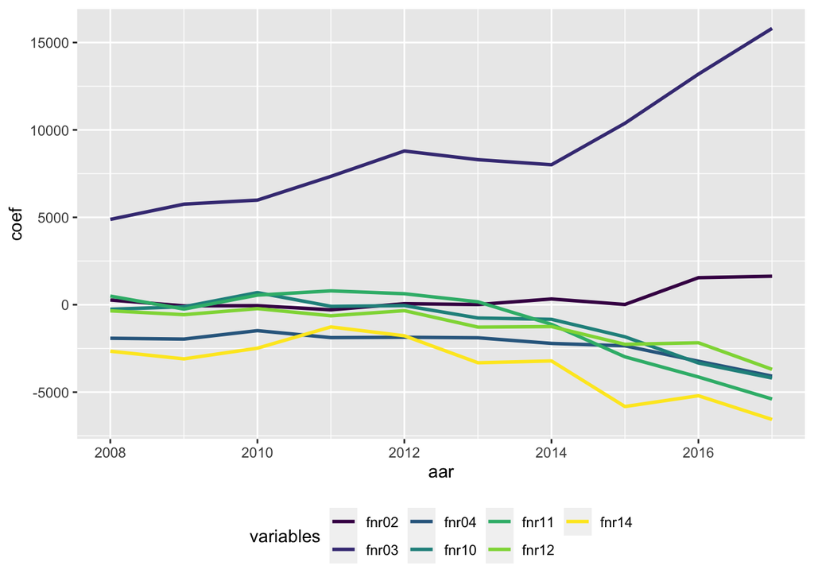

```r
coef_df_long %>%
  select(aar, variables, coef) %>%
  filter(
    variables %in% c("fnr02", "fnr03", "fnr04", "fnr10", "fnr11", "fnr12", "fnr14")
  ) %>%
  ggplot(mapping = aes(x = aar, y = coef, colour = variables)) +
  scale_color_viridis(discrete = TRUE, option = "D") +
  geom_line(aes(group = variables), lwd = 1) +
  theme(legend.position = 'bottom')
```

4. Hva sier plot-et oss om prisutviklingen i disse fylkene?

## iv.

Prisutviklingen er stabil og jevn frem til 2013 vertfall. *fnr03* ligger over de andre fylkene, og stikker ifra de andre fylkene med et enda større “sprik”. De har den største veksten.

## v.

I året 2014 er det året prisene endrer seg mest. De fleste fylkene har en nedover vekst. Dette skyldes nok oljekrisen i 2014.

## i.

Legger til variablene **Total_ya_p**, **inc_k1**, **inc_k5**, **uni_k_mf**, **uni_l_mf** og **Trade_pc_100K**:

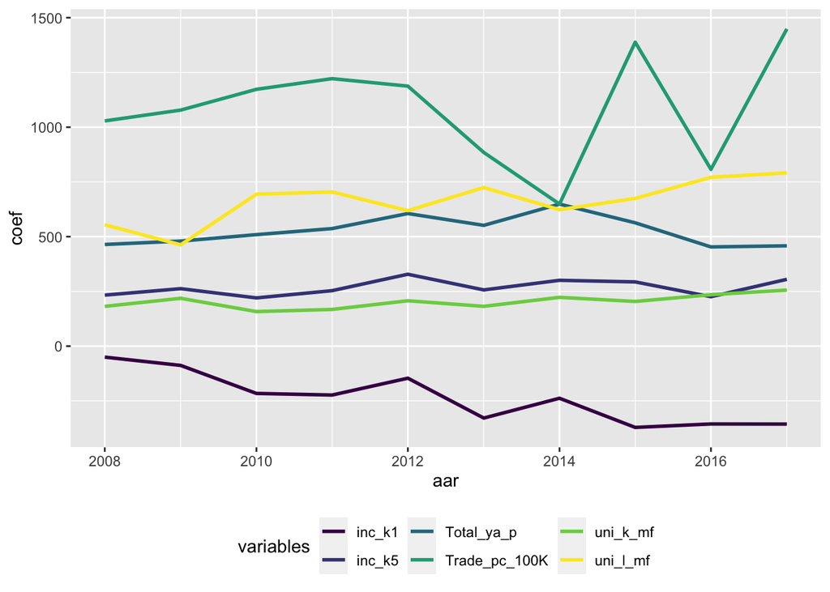

```r
coef_df_long %>%
  select(aar, variables, coef) %>%
  filter(
    variables %in% c("Total_ya_p", "inc_k1", "inc_k5", "uni_k_mf", "uni_l_mf", "Trade_pc_100K")
  ) %>%
  ggplot(mapping = aes(x = aar, y = coef, colour = variables)) +
  scale_color_viridis(discrete = TRUE,
                      option = "D") +
  geom_line(aes(group = variables),
            lwd = 1) +
  theme(legend.position = 'bottom')
```

## ii.

**inc_k5**, **Total_ya_p**, **uni_k_mf** og **uni_l_mf** ser ut til å være de mest stabile variablene over tid.

**inc_k1** kan man vel si er “stabilt nedgående” over tid.

**Trade_pc_100K** er den desidert mest ustabile (mest variasjon).